# Punishment Study 2.1.2 — NLP Integration

# PHASE 4: FACADE CORRELATION ANALYSIS

This is the central descriptive table for Study 2’s “Three Competing Explanations” subsection. We correlate every text feature (rows) with every psychological measure (columns) and visualize the result as a heatmap. The cultural-default thesis predicts most cells should be near zero. The individual-facade thesis predicts negative cells (high-hostile → less prosocial language). Theme-selection effects show up as *selectively* large negative cells (e.g., rehab similarity), while other prosocial themes look flat.

## 4.1 Define the rows (text features) and columns (psychological measures)

```r
# === TEXT FEATURES (rows of facade matrix) ===
# We pick a curated set that spans (a) embedding-based prosocial-dark gaps
# (one per model), (b) classifier-based prosocial-dark gaps, (c) individual
# theme-similarity columns from the workhorse embedding model (BGE), and
# (d) low-level surface features (sentiment, word count).

text_features <- tibble::tribble(
  ~text_var,                          ~text_label,                ~feature_type,
  "bge_orig_b3a_pro_minus_dark",      "BGE pro−dark gap",         "embedding gap",
  "voyage_orig_b3a_pro_minus_dark",   "voyage pro−dark gap",      "embedding gap",
  "mpnet_orig_b3a_pro_minus_dark",    "mpnet pro−dark gap",       "embedding gap",
  "claude_ml_prosocial_minus_dark",   "Claude pro−dark (ML)",     "classifier gap",
  "deberta_ml_prosocial_minus_dark",  "DeBERTa pro−dark (ML)",    "classifier gap",
  "just_prosocial_minus_dark",        "Dictionary pro−dark",      "dictionary gap",
  "vader_compound",                   "VADER compound",           "sentiment",
  "text_combined_wordcount",          "Word count",               "surface",
  "bge_orig_rehabilitation",          "BGE rehab sim",            "theme similarity",
  "bge_orig_suffering",               "BGE suffering sim",        "theme similarity",
  "bge_orig_revenge",                 "BGE revenge sim",          "theme similarity"
)

# === PSYCHOLOGICAL MEASURES (columns of facade matrix) ===
# Mix of cluster aggregates (Punitiveness, Hostile Aggression, Crime
# Concerns) and theoretically informative construct-level composites
# (Hatred, Revenge, Suffering, Exclusion, RWA, Racial Resentment).

psych_measures <- tibble::tribble(
  ~psych_var,             ~psych_label,
  "punitiveness_agg",     "Punitiveness",
  "hostile_agg",          "Hostile Aggression",
  "crime_concerns_agg",   "Crime Concerns",
  "hatred_comp",          "Hatred",
  "revenge_comp",         "Revenge",
  "suffering_comp",       "Suffering",
  "exclusion_comp",       "Exclusion",
  "rwa_comp",             "RWA",
  "raceresent_comp",      "Racial Resentment"
)

cat(sprintf("Facade matrix: %d text features × %d psych measures = %d cells\n\n",
            nrow(text_features), nrow(psych_measures),
            nrow(text_features) * nrow(psych_measures)))
```

```
## Facade matrix: 11 text features × 9 psych measures = 99 cells
```

## 4.2 Compute the full facade correlation matrix

```r
# Loop over every (text, psych) pair and compute one facade_cell()
facade_long <- expand.grid(
  text_var  = text_features$text_var,
  psych_var = psych_measures$psych_var,
  stringsAsFactors = FALSE
)

facade_results <- do.call(rbind, lapply(seq_len(nrow(facade_long)), function(i) {
  facade_cell(nlp,
              facade_long$text_var[i],
              facade_long$psych_var[i])
}))

# Attach human-readable labels
facade_results <- facade_results %>%
  left_join(text_features  %>% select(text_var,  text_label),
            by = c("text"  = "text_var")) %>%
  left_join(psych_measures %>% select(psych_var, psych_label),
            by = c("psych" = "psych_var"))

# Sort by absolute correlation
facade_results <- facade_results %>%
  arrange(desc(abs(r)))

cat("=== FACADE CORRELATION TABLE (top 20 cells by |r|) ===\n\n")
```

```
## === FACADE CORRELATION TABLE (top 20 cells by |r|) ===
```

```r
print(facade_results %>%
        select(TextFeature = text_label, PsychMeasure = psych_label,
               r, p, n, sig) %>%
        head(20),
      row.names = FALSE)
```

```
##            TextFeature       PsychMeasure      r                      p   n sig
##          BGE rehab sim       Punitiveness -0.369 0.00000000000000001789 496 ***
##   Claude pro−dark (ML)       Punitiveness -0.276 0.00000000038088278677 496 ***
##   Claude pro−dark (ML) Hostile Aggression -0.245 0.00000003257945377200 496 ***
##   Claude pro−dark (ML)          Suffering -0.226 0.00000034991844909033 496 ***
##       BGE pro−dark gap       Punitiveness -0.204 0.00000457964051940766 496 ***
##    voyage pro−dark gap       Punitiveness -0.201 0.00000655409367438116 496 ***
##          BGE rehab sim                RWA -0.197 0.00000983397316481711 496 ***
##         VADER compound       Punitiveness -0.193 0.00001455629601270141 496 ***
##   Claude pro−dark (ML)            Revenge -0.193 0.00001462199908572778 496 ***
##   Claude pro−dark (ML)             Hatred -0.180 0.00005394422726222594 496 ***
##          BGE rehab sim             Hatred -0.178 0.00006939401352575766 496 ***
##     mpnet pro−dark gap       Punitiveness -0.172 0.00012271900152713389 496 ***
##  DeBERTa pro−dark (ML)          Suffering -0.172 0.00011993760995297065 496 ***
##  DeBERTa pro−dark (ML) Hostile Aggression -0.167 0.00019484358457299655 496 ***
##  DeBERTa pro−dark (ML)                RWA -0.165 0.00022494728031512151 496 ***
##          BGE rehab sim  Racial Resentment -0.162 0.00028487839854080330 496 ***
##  DeBERTa pro−dark (ML)       Punitiveness -0.161 0.00030770875863450766 496 ***
##  DeBERTa pro−dark (ML)             Hatred -0.161 0.00032667521407426538 496 ***
##          BGE rehab sim Hostile Aggression -0.146 0.00113472074734892198 496  **
##   Claude pro−dark (ML)          Exclusion -0.146 0.00113013414616704687 496  **
```

```r
# Summary stats
n_total       <- nrow(facade_results)
n_sig         <- sum(facade_results$p < .05, na.rm = TRUE)
n_meaningful  <- sum(facade_results$p < .05 & abs(facade_results$r) >= .10, na.rm = TRUE)
n_neg_meaning <- sum(facade_results$p < .05 & facade_results$r <= -.10, na.rm = TRUE)
n_pos_meaning <- sum(facade_results$p < .05 & facade_results$r >=  .10, na.rm = TRUE)

cat(sprintf("\n*** SECTION SUMMARY (Phase 4.2):\n"))
```

```
##
## *** SECTION SUMMARY (Phase 4.2):
```

```r
cat(sprintf("  Cells:                     %d\n", n_total))
```

```
##   Cells:                     99
```

```r
cat(sprintf("  Significant (p < .05):     %d (%.1f%%)\n",
            n_sig, 100 * n_sig / n_total))
```

```
##   Significant (p < .05):     38 (38.4%)
```

```r
cat(sprintf("  Meaningful (|r|≥.10, p<.05): %d (%.1f%%)\n",
            n_meaningful, 100 * n_meaningful / n_total))
```

```
##   Meaningful (|r|≥.10, p<.05): 33 (33.3%)
```

```r
cat(sprintf("  Negative meaningful:       %d\n", n_neg_meaning))
```

```
##   Negative meaningful:       32
```

```r
cat(sprintf("  Positive meaningful:       %d\n", n_pos_meaning))
```

```
##   Positive meaningful:       1
```

```r
cat("  → Pattern: where text features track psychological measures,\n")
```

```
##   → Pattern: where text features track psychological measures,
```

```r
cat("    they almost always do so NEGATIVELY (prosocial framing decreases\n")
```

```
##     they almost always do so NEGATIVELY (prosocial framing decreases
```

```r
cat("    with punitiveness/hostility) — consistent with theme-selection effects. ***\n\n")
```

```
##     with punitiveness/hostility) — consistent with theme-selection effects. ***
```

## 4.3 Facade heatmap visualization

```r
# Build the heatmap with ggplot2 so we can combine r-value and significance
# stars in each cell. corrplot doesn't support both in one tile cleanly.
#
# Each cell shows:
#   - background color: gradient red (negative) → white (zero) → blue (positive)
#   - text:             the r value, followed by significance stars
#                       (* p < .05, ** p < .01, *** p < .001)
#
# Row and column order is preserved from text_features and psych_measures
# specs in section 4.1, so the visual order matches the manuscript narrative
# (embedding gaps, classifier gaps, dictionary gap, surface features,
#  theme similarities — top to bottom).

facade_plot_data <- facade_results %>%
  mutate(
    # Add stars to the r-value label
    cell_label = sprintf("%.2f%s", r, sig),
    # Force the row order: use the order of text_features
    text_label = factor(text_label, levels = rev(text_features$text_label)),
    # Force the column order: use the order of psych_measures
    psych_label = factor(psych_label, levels = psych_measures$psych_label)
  )

facade_heatmap <- ggplot(facade_plot_data,
                          aes(x = psych_label, y = text_label, fill = r)) +
  geom_tile(color = "white", linewidth = 0.4) +
  geom_text(aes(label = cell_label), size = 3, color = "black") +
  scale_fill_gradient2(
    low      = "#B2182B",     # red for negative
    mid      = "white",
    high     = "#2166AC",     # blue for positive
    midpoint = 0,
    limits   = c(-0.40, 0.40),
    name     = "Pearson r"
  ) +
  scale_x_discrete(position = "top") +
  labs(
    title    = "Facade Analysis: Text Features × Psychological Measures",
    subtitle = "Significance: * p < .05, ** p < .01, *** p < .001",
    x        = NULL,
    y        = NULL
  ) +
  theme_minimal(base_size = 11) +
  theme(
    axis.text.x       = element_text(angle = 45, hjust = 0, vjust = 0,
                                      face = "bold"),
    axis.text.y       = element_text(face = "bold"),
    panel.grid        = element_blank(),
    plot.title        = element_text(face = "bold", size = 13, hjust = 0.5),
    plot.subtitle     = element_text(size = 9, hjust = 0.5,
                                      color = "grey30"),
    legend.position   = "right",
    legend.key.height = unit(1.5, "cm")
  )

# Save to file
ggsave(filename = file.path(OUT_FIGURES_NLP, "facade_correlations_heatmap.png"),
       plot     = facade_heatmap,
       width    = 11,
       height   = 8,
       dpi      = 150,
       bg       = "white")

cat("Saved: facade_correlations_heatmap.png\n")
```

```
## Saved: facade_correlations_heatmap.png
```

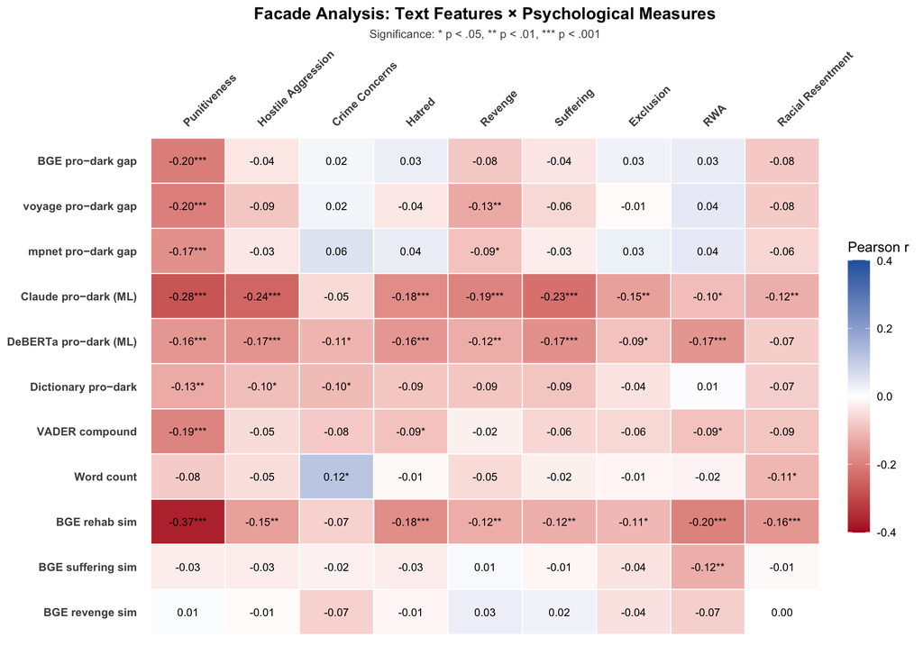

```r
# Also display in the rendered HTML
print(facade_heatmap)
```

## 4.4 Save full facade table

```r
write.csv(facade_results %>%
            select(TextFeature = text_label, PsychMeasure = psych_label,
                   r, p, N = n, sig),
          file.path(OUT_TABLES_NLP, "facade_correlations_full.csv"),
          row.names = FALSE)
cat("Saved: facade_correlations_full.csv\n\n")
```

```
## Saved: facade_correlations_full.csv
```

# PHASE 5: MISMATCH MULTIVERSE — THREE COMPETING HYPOTHESES

This phase operationalizes the manuscript’s “Three Competing Explanations” subsection. We test, for each of six different prosocial-dark gap operationalizations, whether hostile aggression and crime concerns correlate with the gap, and assign a verdict among:

- **Individual Facade**: r(hostile, gap) is significantly negative (high-hostile individuals use less prosocial language to mask dark motives).
- **Sincerity**: r(crime, gap) is significantly positive (high-crime-concern individuals use more prosocial language because they genuinely have prosocial motives).
- **Cultural Default**: both correlations are near zero (everyone uses similar amounts of prosocial language; the framing is a shared rhetorical script independent of psychology).

Per Dan Comment 519, these three hypotheses are described before predictions are stated.

## 5.1 Define the six gap operationalizations

```r
# Three embedding-based gaps (BGE, voyage, mpnet) and three
# classifier-based gaps (Claude ML, DeBERTa ML, Dictionary).

gap_specs <- tibble::tribble(
  ~gap_var,                            ~gap_label,
  "bge_orig_b3a_pro_minus_dark",       "BGE",
  "voyage_orig_b3a_pro_minus_dark",    "voyage",
  "mpnet_orig_b3a_pro_minus_dark",     "mpnet",
  "claude_ml_prosocial_minus_dark",    "Claude ML",
  "deberta_ml_prosocial_minus_dark",   "DeBERTa ML",
  "just_prosocial_minus_dark",         "Dictionary"
)

cat(sprintf("Testing %d gap operationalizations across 3 hypotheses each.\n\n",
            nrow(gap_specs)))
```

```
## Testing 6 gap operationalizations across 3 hypotheses each.
```

## 5.2 Compute the multiverse table

```r
# Verdict logic:
#   - If r(hostile) is sig negative AND |r(hostile)| > |r(crime)| → Individual Facade
#   - Else if r(crime) is sig positive → Sincerity
#   - Else → Cultural Default
# This implements the description in Dan-comment-519 ordering: predictions
# stated AFTER hypotheses described above.

multiverse <- data.frame(
  TextFeature = character(),
  r_hostile   = numeric(),
  p_hostile   = numeric(),
  r_crime     = numeric(),
  p_crime     = numeric(),
  Verdict     = character(),
  stringsAsFactors = FALSE
)

for (i in seq_len(nrow(gap_specs))) {
  gv <- gap_specs$gap_var[i]
  gl <- gap_specs$gap_label[i]

  if (!(gv %in% names(nlp))) next

  # r(gap, hostile_agg)
  th <- cor.test(nlp[[gv]], nlp$hostile_agg)
  rh <- unname(th$estimate); ph <- th$p.value

  # r(gap, crime_concerns_agg)
  tc <- cor.test(nlp[[gv]], nlp$crime_concerns_agg)
  rc <- unname(tc$estimate); pc <- tc$p.value

  verdict <- if (ph < .05 && rh < 0 && abs(rh) > abs(rc)) {
    "INDIVIDUAL FACADE"
  } else if (pc < .05 && rc > 0) {
    "SINCERITY"
  } else {
    "CULTURAL DEFAULT"
  }

  multiverse <- rbind(multiverse, data.frame(
    TextFeature = gl,
    r_hostile   = round(rh, 4),
    p_hostile   = round(ph, 4),
    r_crime     = round(rc, 4),
    p_crime     = round(pc, 4),
    Verdict     = verdict
  ))
}

cat("=== MULTIVERSE TEST OF MISMATCH HYPOTHESES ===\n\n")
```

```
## === MULTIVERSE TEST OF MISMATCH HYPOTHESES ===
```

```r
print(multiverse, row.names = FALSE)
```

```
##  TextFeature r_hostile p_hostile r_crime p_crime           Verdict
##          BGE   -0.0370    0.4111  0.0184  0.6827  CULTURAL DEFAULT
##       voyage   -0.0845    0.0599  0.0223  0.6210  CULTURAL DEFAULT
##        mpnet   -0.0342    0.4478  0.0572  0.2031  CULTURAL DEFAULT
##    Claude ML   -0.2450    0.0000 -0.0538  0.2317 INDIVIDUAL FACADE
##   DeBERTa ML   -0.1665    0.0002 -0.1145  0.0107 INDIVIDUAL FACADE
##   Dictionary   -0.0959    0.0327 -0.1046  0.0198  CULTURAL DEFAULT
```

```r
n_cd <- sum(multiverse$Verdict == "CULTURAL DEFAULT")
n_if <- sum(multiverse$Verdict == "INDIVIDUAL FACADE")
n_si <- sum(multiverse$Verdict == "SINCERITY")

cat(sprintf("\n*** SECTION SUMMARY (Phase 5.2):\n"))
```

```
##
## *** SECTION SUMMARY (Phase 5.2):
```

```r
cat(sprintf("  Cultural Default:   %d/%d  (embedding-based gaps)\n",
            n_cd, nrow(multiverse)))
```

```
##   Cultural Default:   4/6  (embedding-based gaps)
```

```r
cat(sprintf("  Individual Facade:  %d/%d  (classifier-based gaps)\n",
            n_if, nrow(multiverse)))
```

```
##   Individual Facade:  2/6  (classifier-based gaps)
```

```r
cat(sprintf("  Sincerity:          %d/%d\n", n_si, nrow(multiverse)))
```

```
##   Sincerity:          0/6
```

```r
cat("  → The verdict pattern reveals method-class divergence: surface\n")
```

```
##   → The verdict pattern reveals method-class divergence: surface
```

```r
cat("    prosocial-vocabulary similarity (embeddings) is independent\n")
```

```
##     prosocial-vocabulary similarity (embeddings) is independent
```

```r
cat("    of hostility, but classifier-detected theme selection IS\n")
```

```
##     of hostility, but classifier-detected theme selection IS
```

```r
cat("    associated with hostility. Both findings are robust within\n")
```

```
##     associated with hostility. Both findings are robust within
```

```r
cat("    their respective method classes. ***\n\n")
```

```
##     their respective method classes. ***
```

## 5.3 Save multiverse table

```r
write.csv(multiverse,
          file.path(OUT_TABLES_NLP, "mismatch_multiverse.csv"),
          row.names = FALSE)
cat("Saved: mismatch_multiverse.csv\n\n")
```

```
## Saved: mismatch_multiverse.csv
```